# Multilevel Regression: Examples and Basics

Presented by AG Schissler

04/27/2020

```r
knitr::opts_chunk$set(echo = TRUE)
knitr::opts_chunk$set(cache=TRUE, autodep=TRUE, cache.comments=TRUE)
suppressMessages(library(ggplot2))
suppressMessages(library(arm))
suppressMessages(library(R2OpenBUGS))
suppressMessages(library(lme4)) ## for lmer
suppressMessages(library(foreign))
```

## Today’s lesson is derived from Gelman and Hill Ch. 11, 12

Most of these notes are direct quotes, paraphrases, and adaptations from

[Data Analysis Using Regression and Multilevel/Hierarchical Models (Gelman and Hill 2007)](http://www.stat.columbia.edu/~gelman/arm/)

Your exercises will also be derived from the same textbook. You can find data sets and examples here:

http://www.stat.columbia.edu/~gelman/arm/software/

## A note about the coding practices for the examples

The examples below frequently attach objects to the `R` global environment and to the `R2BUGS` search path. This works okay in isolation, but can be dangerous when objects have the same name and other scoping issues. I recommend to keep data in a data structure (`data.frame`, `matrix`, etc). And reference that object (instead of extracting vectors to use separate). It keeps things tidy and is safer. Also `R2BUGS`interactively requests confirmation for `attach.all` which is a pain when knitting your `rmarkdown` (not sure if RStudio handles this automatically, but you can try this from the command line `R -e "rmarkdown::render('25_Multilevel_Reg_27apr2020.Rmd')"` to run noninteratively). Also many values are *hardcoded* instead of done in a dynamic way. Moreover, it is more natural in `R` to write functions for repeated tasks and avoid loops (and use the `apply` family of functions). Please keep that in mind as you reuse the code in your assignments and projects (and future work).

## Ch. 11 Multilevel structures

### 11.1 Varying-intercept and varying-slope models

With groups data, a regression that includes indicators for groups in called a *varying-intercept model* because it can be interpreted as a model with a different intercept for each group.

Varying-intercept model:
$$y_i = \alpha_{j[i]} + \beta x_i + \epsilon_i.$$

Varying-slope model:
$$y_i = \alpha + \beta_{j[i]} x_i + \epsilon_i.$$

Varying-intercept and varying-slope model:
$$y_i = \alpha_{j[i]} + \beta_{j[i]} x_i + \epsilon_i.$$

### 11.4 Indicator variables and fixed / random effects

- One can specify and fit a multilevel model in a classical way: Include $J-1$ indicator variables it a standard linear regression. But this can cause problems in estimating these effects. It is better to specify and estimate these quantities using multilevel model software.
- Note that the definitions/notions of fixed/random effects from classical “mixed effects” literature and applied regression textbook descriptions are confusing and contradictory. Using phrases like “multilevel model with varying intercepts and varying slopes” is more clear and modern.

## Ch. 12 Multilevel linear models: the basics

### 12.1 Notation

- Units. $i = 1, \ldots, n$. By *units* we mean the smallest items of measurement.
- Outcome measurements $y = (y_i, \ldots, y_n)$. These are the unit-level data being modeled.
- Regression predictors represented by an $n \times k$ matrix $X$. So that the predicted values are $\hat{y} = X \beta$.
- For each individual unit $i$, we denote its row vector of predictors as $X_i$.

### 12.2 Partial pooling with no predictors

```r
## Read & clean the data
# get radon data
# Data are at http://www.stat.columbia.edu/~gelman/arm/examples/radon
## Read & clean the data
# get radon data
# Data are at http://www.stat.columbia.edu/~gelman/arm/examples/radon
library ("arm")

srrs2 <- read.table ("srrs2.dat", header=T, sep=",")
mn <- srrs2$state=="MN"
radon <- srrs2$activity[mn]
log.radon <- log (ifelse (radon==0, .1, radon))
floor <- srrs2$floor[mn]       # 0 for basement, 1 for first floor
n <- length(radon)
y <- log.radon
x <- floor

# get county index variable
county.name <- as.vector(srrs2$county[mn])
uniq <- unique(county.name)
J <- length(uniq)
county <- rep (NA, J)
for (i in 1:J){
  county[county.name==uniq[i]] <- i
}

 # no predictors
ybarbar = mean(y)

sample.size <- as.vector (table (county))
sample.size.jittered <- sample.size*exp (runif (J, -.1, .1))
cty.mns = tapply(y,county,mean)
cty.vars = tapply(y,county,var)
cty.sds = mean(sqrt(cty.vars[!is.na(cty.vars)]))/sqrt(sample.size)
cty.sds.sep = sqrt(tapply(y,county,var)/sample.size)

## varying-intercept model, no predictors

mlm.radon.nopred <- lmer(y ~ 1 + (1 | county) )

## Figure 12.1 (a)

par(mfrow=c(1,2))
plot (sample.size.jittered, cty.mns, cex.lab=.9, cex.axis=1,
      xlab="sample size in county j",
      ylab="avg. log radon in county j",
      pch=20, log="x", cex=.3, mgp=c(1.5,.5,0),
      ylim=c(0,3.2), yaxt="n", xaxt="n")
axis (1, c(1,3,10,30,100), cex.axis=.9, mgp=c(1.5,.5,0))
axis (2, seq(0,3), cex.axis=.9, mgp=c(1.5,.5,0))
for (j in 1:J){
  lines (rep(sample.size.jittered[j],2),
         cty.mns[j] + c(-1,1)*cty.sds[j], lwd=.5)
#         cty.mns[j] + c(-1,1)*mean(cty.sds[!is.na(cty.sds)]), lwd=.5)
}
## abline(h=mlm.radon.nopred$median$mu.a)
abline(h=median(unlist(ranef(mlm.radon.nopred))))
title("No pooling",cex.main=.9, line=1)
#abline(h=ybarbar)
points(sample.size.jittered[36],cty.mns[36],cex=4)

## Figure 12.1 (b)

plot (sample.size.jittered, median(unlist(ranef(mlm.radon.nopred))), cex.lab=.9, cex.axis=1,
      xlab="sample size in county j",
      ylab="avg. log radon in county j",
      pch=20, log="x", cex=.3, mgp=c(1.5,.5,0),
      ylim=c(0,3.2), yaxt="n", xaxt="n")
axis (1, c(1,3,10,30,100), cex.axis=.9, mgp=c(1.5,.5,0))
axis (2, seq(0,3), cex.axis=.9, mgp=c(1.5,.5,0))
for (j in 1:J){
  lines (rep(sample.size.jittered[j],2),
         unname(unlist(ranef(mlm.radon.nopred))) + c(-1,1)*unname(unlist(se.ranef(mlm.radon.nopred))),
      lwd=.5)
}
abline(h=mlm.radon.nopred$median$mu.a)
points(sample.size.jittered[36],mlm.radon.nopred$median$a[36],cex=4)#,col="red")
title("Multilevel model",cex.main=.9, line=1)
```

[output not shown]

### 12.3 Partial pooling with predictors

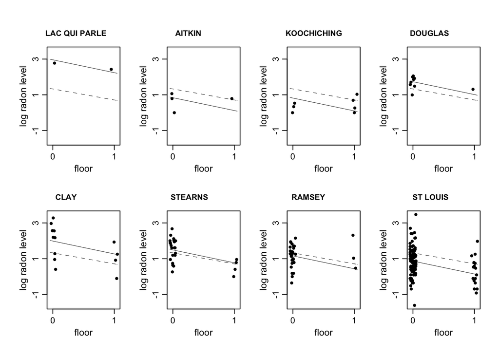

```r
## Read the data
# Data are at http://www.stat.columbia.edu/~gelman/arm/examples/radon

# The R codes & data files should be saved in the same directory for
# the source command to work

# source("12.2_Partial pooling with no predictors.R") # where data was cleaned
# close the Bugs window to proceed

## Complete pooling regression
lm.pooled <- lm (y ~ x)
## display (lm.pooled)

## No pooling regression
lm.unpooled <- lm (y ~ x + factor(county) -1)
## display (lm.unpooled)

## Comparing-complete pooling & no-pooling (Figure 12.2)
x.jitter <- x + runif(n,-.05,.05)
display8 <- c (36, 1, 35, 21, 14, 71, 61, 70)  # counties to be displayed
y.range <- range (y[!is.na(match(county,display8))])

par (mfrow=c(2,4), mar=c(4,4,3,1), oma=c(1,1,2,1))
for (j in display8){
  plot (x.jitter[county==j], y[county==j], xlim=c(-.05,1.05), ylim=y.range,
        xlab="floor", ylab="log radon level", cex.lab=1.2, cex.axis=1.1,
        pch=20, mgp=c(2,.7,0), xaxt="n", yaxt="n", cex.main=1,
        main=uniq[j])
  axis (1, c(0,1), mgp=c(2,.7,0), cex.axis=1.1)
  axis (2, seq(-1,3,2), mgp=c(2,.7,0), cex.axis=1.1)
  curve (coef(lm.pooled)[1] + coef(lm.pooled)[2]*x, lwd=.5, lty=2, add=TRUE)
  curve (coef(lm.unpooled)[j+1] + coef(lm.unpooled)[1]*x, lwd=.5, add=TRUE)
}
```

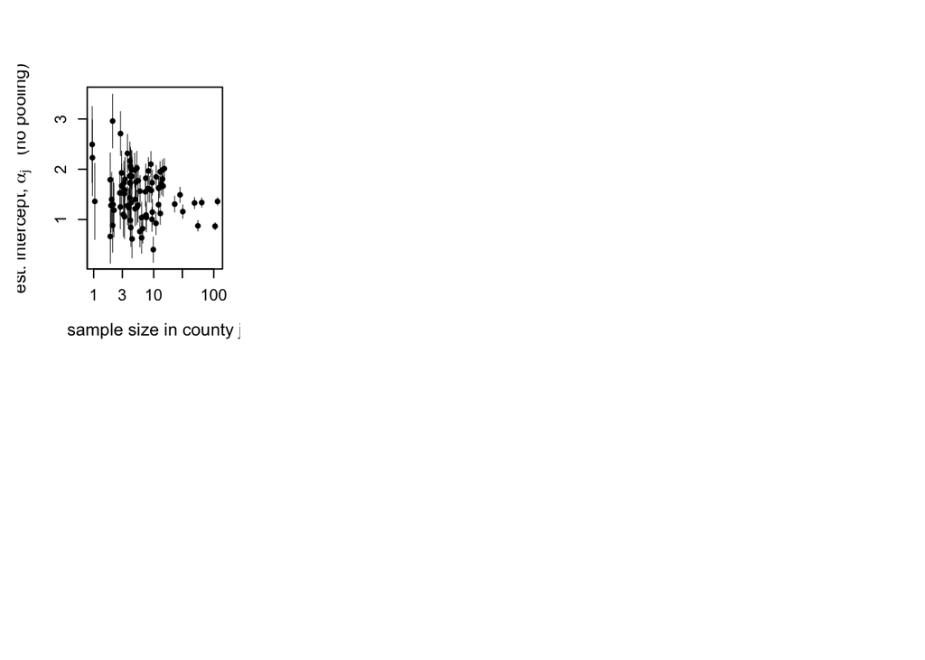

```r
## No-pooling ests vs. sample size (plot on the left on figure 12.3)
sample.size <- as.vector (table (county))
sample.size.jittered <- sample.size*exp (runif (J, -.1, .1))

## plot.new()
## par (mar=c(5,5,4,2)+.1)
plot (sample.size.jittered, coef(lm.unpooled)[-1], cex.lab=1.2, cex.axis=1.2,
  xlab="sample size in county j", ylab=expression (paste
  ("est. intercept, ", alpha[j], "   (no pooling)")),
  pch=20, log="x", ylim=c(.15,3.5), yaxt="n", xaxt="n")
axis (1, c(1,3,10,30,100), cex.axis=1.1)
axis (2, seq(0,3), cex.axis=1.1)
for (j in 1:J){
  lines (rep(sample.size.jittered[j],2),
    coef(lm.unpooled)[j+1] + c(-1,1)*se.coef(lm.unpooled)[j+1], lwd=.5)
}

## Complete pooling regression
lm.pooled <- lm (y ~ x)
## display (lm.pooled)

## No pooling regression
lm.unpooled <- lm (y ~ x + factor(county) -1)
## display (lm.unpooled)

## Comparing-complete pooling & no-pooling (Figure 12.2)
x.jitter <- x + runif(n,-.05,.05)
display8 <- c (36, 1, 35, 21, 14, 71, 61, 70)  # counties to be displayed
y.range <- range (y[!is.na(match(county,display8))])

par (mfrow=c(2,4), mar=c(4,4,3,1), oma=c(1,1,2,1))
```

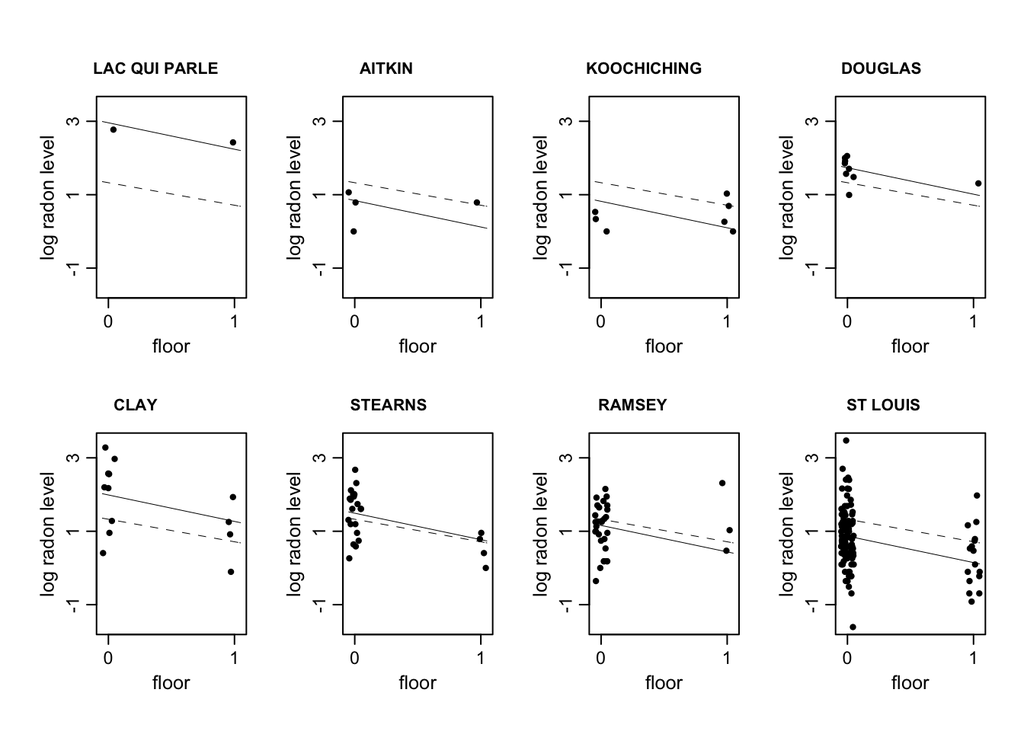

```r
for (j in display8){
  plot (x.jitter[county==j], y[county==j], xlim=c(-.05,1.05), ylim=y.range,
        xlab="floor", ylab="log radon level", cex.lab=1.2, cex.axis=1.1,
        pch=20, mgp=c(2,.7,0), xaxt="n", yaxt="n", cex.main=1,
        main=uniq[j])
  axis (1, c(0,1), mgp=c(2,.7,0), cex.axis=1.1)
  axis (2, seq(-1,3,2), mgp=c(2,.7,0), cex.axis=1.1)
  curve (coef(lm.pooled)[1] + coef(lm.pooled)[2]*x, lwd=.5, lty=2, add=TRUE)
  curve (coef(lm.unpooled)[j+1] + coef(lm.unpooled)[1]*x, lwd=.5, add=TRUE)
}
```

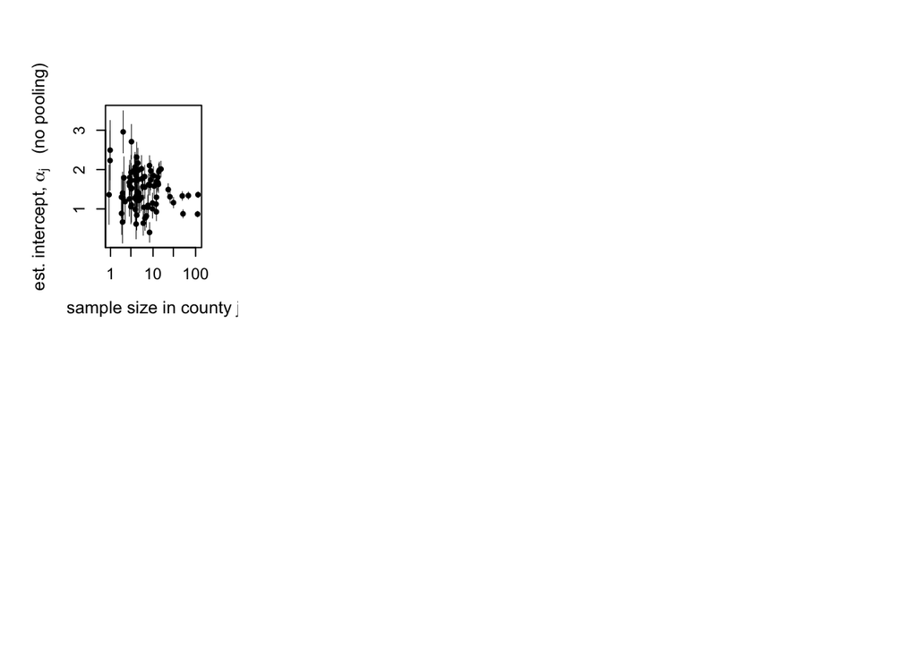

```r
## No-pooling ests vs. sample size (plot on the left on figure 12.3)
sample.size <- as.vector (table (county))
sample.size.jittered <- sample.size*exp (runif (J, -.1, .1))

par (mar=c(5,5,4,2)+.1)
plot (sample.size.jittered, coef(lm.unpooled)[-1], cex.lab=1.2, cex.axis=1.2,
  xlab="sample size in county j", ylab=expression (paste
  ("est. intercept, ", alpha[j], "   (no pooling)")),
  pch=20, log="x", ylim=c(.15,3.5), yaxt="n", xaxt="n")
axis (1, c(1,3,10,30,100), cex.axis=1.1)
axis (2, seq(0,3), cex.axis=1.1)
for (j in 1:J){
  lines (rep(sample.size.jittered[j],2),
    coef(lm.unpooled)[j+1] + c(-1,1)*se.coef(lm.unpooled)[j+1], lwd=.5)
}
```

### 12.4 Quickling fitting multilevel predictors in R

```r
## Read the data
# Data are at http://www.stat.columbia.edu/~gelman/arm/examples/radon

# The R codes & data files should be saved in the same directory for
# the source command to work

## source("12.3_Partial pooling with predictors.R") # where variables were defined
# close the Bugs window to proceed

## Varying-intercept model w/ no predictors
M0 <- lmer (y ~ 1 + (1 | county))
display (M0)
```

```
## lmer(formula = y ~ 1 + (1 | county))
## coef.est  coef.se
##     1.31     0.05
##
## Error terms:
##  Groups   Name        Std.Dev.
##  county   (Intercept) 0.31
##  Residual             0.80
## ---
## number of obs: 919, groups: county, 85
## AIC = 2265.4, DIC = 2251
## deviance = 2255.2
```

```r
## Including x as a predictor
M1 <- lmer (y ~ x + (1 | county))
display (M1)
```

```
## lmer(formula = y ~ x + (1 | county))
##             coef.est coef.se
## (Intercept)  1.46     0.05
## x           -0.69     0.07
##
## Error terms:
##  Groups   Name        Std.Dev.
##  county   (Intercept) 0.33
##  Residual             0.76
## ---
## number of obs: 919, groups: county, 85
## AIC = 2179.3, DIC = 2156
## deviance = 2163.7
```

```r
  # estimated regression coefficicents
coef (M1)
```

```
## $county
##    (Intercept)          x
## 1    1.1915004 -0.6929937
## 2    0.9276468 -0.6929937
## 3    1.4792143 -0.6929937
## 4    1.5045012 -0.6929937
## 5    1.4461503 -0.6929937
## 6    1.4801817 -0.6929937
## 7    1.8581255 -0.6929937
## 8    1.6827736 -0.6929937
## 9    1.1600747 -0.6929937
## 10   1.5086099 -0.6929937
## 11   1.4322449 -0.6929937
## 12   1.5771520 -0.6929937
## 13   1.2370518 -0.6929937
```

[output cut: 75 more lines]

```r
  # fixed and random effects
fixef (M1)
```

```
## (Intercept)           x
##   1.4615979  -0.6929937
```

```r
ranef (M1)
```

```
## $county
##    (Intercept)
## 1  -0.27009750
## 2  -0.53395107
## 3   0.01761646
## 4   0.04290331
## 5  -0.01544759
## 6   0.01858386
## 7   0.39652761
## 8   0.22117571
## 9  -0.30152320
## 10  0.04701206
## 11 -0.02935302
## 12  0.11555412
## 13 -0.22454606
```

[output cut: 74 more lines]

```r
  # uncertainties in the estimated coefficients
se.fixef (M1)
```

```
## (Intercept)           x
##  0.05157622  0.07043081
```

```r
se.ranef (M1)
```

```
## $county
##    (Intercept)
## 1   0.24777407
## 2   0.09981833
## 3   0.26227669
## 4   0.21544774
## 5   0.24777407
## 6   0.26227669
## 7   0.17199375
## 8   0.24777407
## 9   0.19317328
## 10  0.22477917
## 11  0.23543856
## 12  0.24777407
## 13  0.22477917
```

[output cut: 72 more lines]

```r
  # 95% CI for the slope
fixef(M1)["x"] + c(-2,2)*se.fixef(M1)["x"]
```

```
## [1] -0.8338554 -0.5521321
```

```r
#or
fixef(M1)[2] + c(-2,2)*se.fixef(M1)[2]
```

```
## [1] -0.8338554 -0.5521321
```

```r
  # 95% CI for the intercept in county 26
coef(M1)$county[26,1] + c(-2,2)*se.ranef(M1)$county[26]
```

```
## [1] 1.218798 1.506577
```

```r
  # 95% CI for the error in the intercept in county 26
as.matrix(ranef(M1)$county)[26] + c(-2,2)*se.ranef(M1)$county[26]
```

```
## [1] -0.24279987  0.04497902
```

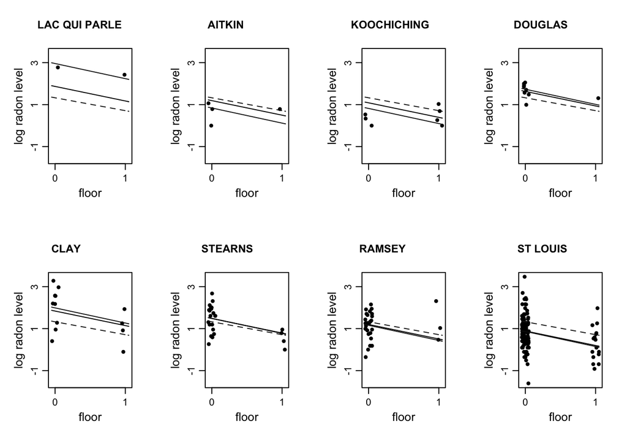

```r
  # to plot Figure 12.4
a.hat.M1 <- coef(M1)$county[,1]                # 1st column is the intercept
b.hat.M1 <- coef(M1)$county[,2]                # 2nd element is the slope

par (mfrow=c(2,4))
for (j in display8){
  plot (x.jitter[county==j], y[county==j], xlim=c(-.05,1.05), ylim=y.range,
    xlab="floor", ylab="log radon level", main=uniq[j],cex.lab=1.2,
    cex.axis=1.1, pch=20, mgp=c(2,.7,0), xaxt="n", yaxt="n", cex.main=1.1)
  axis (1, c(0,1), mgp=c(2,.7,0), cex.axis=1)
  axis (2, c(-1,1,3), mgp=c(2,.7,0), cex.axis=1)
  curve (coef(lm.pooled)[1] + coef(lm.pooled)[2]*x, lty=2, col="gray10", add=TRUE)
  curve (coef(lm.unpooled)[j+1] + coef(lm.unpooled)[1]*x, col="gray10", add=TRUE)
  curve (a.hat.M1[j] + b.hat.M1[j]*x, lwd=1, col="black", add=TRUE)
}
```

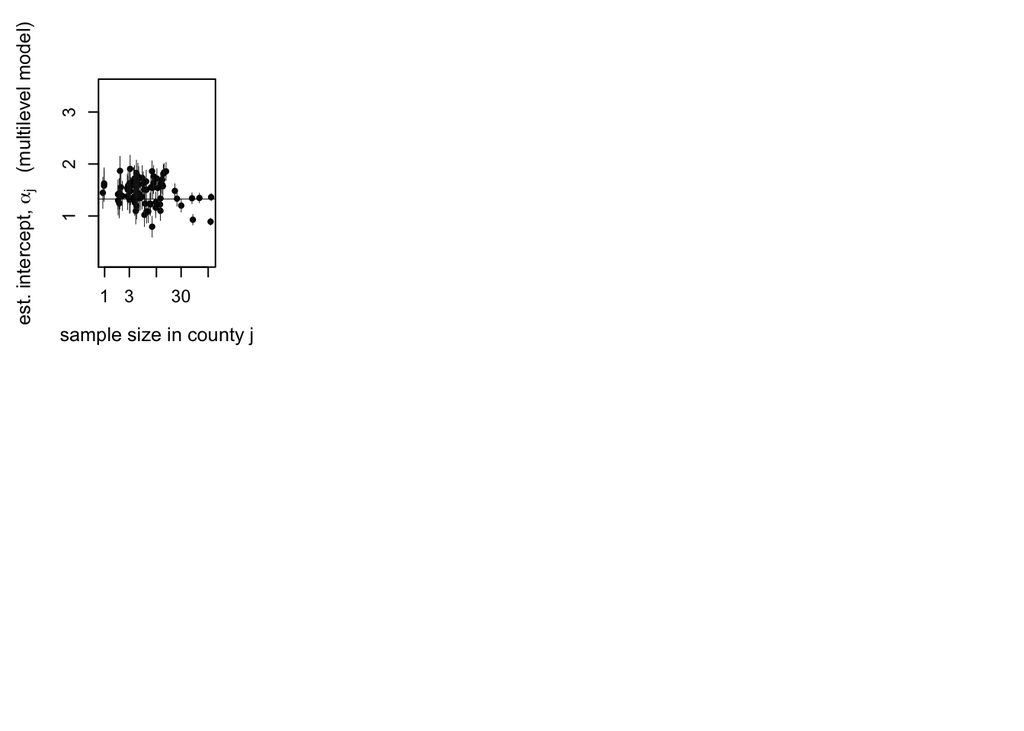

```r
## Multilevel model ests vs. sample size (plot on the right on figure 12.3)
a.se.M1 <- se.coef(M1)$county

par (mar=c(5,5,4,2)+.1)
plot (sample.size.jittered, t(a.hat.M1), cex.lab=1.2, cex.axis=1.1,
  xlab="sample size in county j", ylab=expression (paste
  ("est. intercept, ", alpha[j], "   (multilevel model)")),
  pch=20, log="x", ylim=c(.15,3.5), yaxt="n", xaxt="n")
axis (1, c(1,3,10,30,100), cex.axis=1.1)
axis (2, seq(0,3), cex.axis=1.1)
for (j in 1:J){
  lines (rep(sample.size.jittered[j],2),
    as.vector(a.hat.M1[j]) + c(-1,1)*a.se.M1[j], lwd=.5, col="gray10")
}
abline (coef(lm.pooled)[1], 0, lwd=.5)
```